# Chicago Bulls: Best Five Starting Players Analysis

Pushpak_Jalibili

2023-05-07

### INTRODUCTION

BasketBall, game played between two teams of five players each on rectangular court,usually indoors. Each team tries to score by tossing the ball through opponets goal, an elevated horizontal loop and net called a basket.

The Objective of the game is to score more points than the opposing team by shooting the ball through opponent’s basket.

### Description of the Scenario

As a data analyst for the Chicago Bulls, I have been given the task to find the best starting five players for the team for the upcoming NBA season, while keeping in mind the team’s budget constraints. The team’s poor performance in the previous season and limited budget make this task challenging, but with the help of data analysis, I hope to provide recommendations that will lead to a successful season for the team.

To accomplish this task, I will need to gather data on player performance, including key metrics such as points, field goal percentage, rebounds, assists, steals, and blocks. I will also need to consider each player’s position requirements and responsibilities, as outlined in the background information provided.

Using R, I will filter and clean the data to include only players that the Chicago Bulls can afford within their budget. I will then use statistical analysis and machine learning techniques to identify the top players for each position and evaluate their potential contributions to the team’s success. Finally, I will present my findings and recommendations in a reproducible data analysis project, complete with visualizations and an R Markdown report that can be easily shared with the general manager and other stakeholders.

## Aim Of the Project

The aim of this project is to help the Chicago Bulls, a professional basketball team in the NBA, find the best starting five players within their budget constraints for the upcoming season. By analyzing player performance data and considering position requirements, the project aims to provide recommendations that will improve the team’s chances of success on the court.

## Justification and Importance

Performance Improvement: The Chicago Bulls placed 27th out of 30 teams in the previous NBA season. By strategically selecting the best starting players, the team has an opportunity to improve its performance and competitiveness in the upcoming season. This scenario allows the team to make data-driven decisions based on player performance and cost-effectiveness.

Budget Optimization: With a budget of $118 million, ranked 26th out of 30 teams, the Chicago Bulls need to optimize their financial resources to build a well-rounded roster. This scenario ensures that the team’s limited budget is allocated efficiently, allowing for the acquisition of talented players while staying within financial constraints

Data-Driven Decision Making: Data analysis provides valuable insights and objective evaluation of player performance. By utilizing statistical metrics and value scores, the scenario enables the Chicago Bulls to make informed decisions based on empirical evidence rather than relying solely on subjective judgments or biases. This approach increases the likelihood of selecting players who can contribute positively to the team’s performance.

Overall, the justification and importance of this scenario lie in its potential to enhance team performance, optimize budget allocation, promote long-term planning, facilitate data-driven decision making, and ensure financial sustainability for the Chicago Bulls. By analyzing player data and making informed choices, the team can strive for improved results and create a stronger foundation for future success.

# Data Collection

- Description Of Five Datasets which are used for Analyis.
- Player Statistics
- Player Salaries
- Team Statistics
- Team payroll
- Team Statistics_2

# Data Preparation.

**Loading Libraries**

```r
library(tidyverse)
```

```r
library(ggplot2)
library(car)
library(corrplot)
library(broom)
```

```r
player_stats <- read_csv("data/2018-19_nba_player-statistics.csv",show_col_types = FALSE)
team_stats_1 <- read_csv("data/2018-19_nba_team-statistics_1.csv",show_col_types = FALSE)
team_stats_2 <- read_csv("data/2018-19_nba_team-statistics_2.csv",show_col_types = FALSE)
salary <- read_csv("data/2018-19_nba_player-salaries.csv",show_col_types = FALSE)
payroll <- read_csv("data/2019-20_nba_team-payroll.csv",show_col_types = FALSE)
```

**Structue and Dimensions of Data**

```r
str(player_stats)
```

```
## spec_tbl_df [708 × 29] (S3: spec_tbl_df/tbl_df/tbl/data.frame)
##  $ player_name: chr [1:708] "Alex Abrines" "Quincy Acy" "Jaylen Adams" "Steven Adams" ...
##  $ Pos        : chr [1:708] "SG" "PF" "PG" "C" ...
##  $ Age        : num [1:708] 25 28 22 25 21 21 25 33 21 23 ...
##  $ Tm         : chr [1:708] "OKC" "PHO" "ATL" "OKC" ...
##  $ G          : num [1:708] 31 10 34 80 82 19 7 81 10 38 ...
##  $ GS         : num [1:708] 2 0 1 80 28 3 0 81 1 2 ...
##  $ MP         : num [1:708] 588 123 428 2669 1913 ...
##  $ FG         : num [1:708] 56 4 38 481 280 11 3 684 13 67 ...
##  $ FGA        : num [1:708] 157 18 110 809 486 ...
##  $ FG%        : num [1:708] 0.357 0.222 0.345 0.595 0.576 0.306 0.3 0.519 0.333 0.376 ...
##  $ 3P         : num [1:708] 41 2 25 0 3 6 0 10 3 32 ...
##  $ 3PA        : num [1:708] 127 15 74 2 15 23 4 42 12 99 ...
##  $ 3P%        : num [1:708] 0.323 0.133 0.338 0 0.2 0.261 0 0.238 0.25 0.323 ...
##  $ 2P         : num [1:708] 15 2 13 481 277 5 3 674 10 35 ...
##  $ 2PA        : num [1:708] 30 3 36 807 471 ...
##  $ 2P%        : num [1:708] 0.5 0.667 0.361 0.596 0.588 0.385 0.5 0.528 0.37 0.443 ...
##  $ eFG%       : num [1:708] 0.487 0.278 0.459 0.595 0.579 0.389 0.3 0.522 0.372 0.466 ...
##  $ FT         : num [1:708] 12 7 7 146 166 4 1 349 8 45 ...
##  $ FTA        : num [1:708] 13 10 9 292 226 4 2 412 12 60 ...
##  $ FT%        : num [1:708] 0.923 0.7 0.778 0.5 0.735 1 0.5 0.847 0.667 0.75 ...
##  $ ORB        : num [1:708] 5 3 11 391 165 3 1 251 11 3 ...
##  $ DRB        : num [1:708] 43 22 49 369 432 16 3 493 15 20 ...
##  $ TRB        : num [1:708] 48 25 60 760 597 19 4 744 26 23 ...
##  $ AST        : num [1:708] 20 8 65 124 184 5 6 194 13 25 ...
##  $ STL        : num [1:708] 17 1 14 117 71 1 2 43 1 6 ...
##  $ BLK        : num [1:708] 6 4 5 76 65 4 0 107 0 6 ...
##  $ TOV        : num [1:708] 14 4 28 135 121 6 2 144 8 33 ...
##  $ PF         : num [1:708] 53 24 45 204 203 13 4 179 7 47 ...
##  $ PTS        : num [1:708] 165 17 108 1108 729 ...
##  - attr(*, "spec")=
##   .. cols(
##   ..   player_name = col_character(),
##   ..   Pos = col_character(),
##   ..   Age = col_double(),
##   ..   Tm = col_character(),
##   ..   G = col_double(),
##   ..   GS = col_double(),
##   ..   MP = col_double(),
##   ..   FG = col_double(),
```

[output cut: 8 more lines]

```
##   ..   `eFG%` = col_double(),
##   ..   FT = col_double(),
##   ..   FTA = col_double(),
##   ..   `FT%` = col_double(),
##   ..   ORB = col_double(),
##   ..   DRB = col_double(),
##   ..   TRB = col_double(),
##   ..   AST = col_double(),
##   ..   STL = col_double(),
##   ..   BLK = col_double(),
##   ..   TOV = col_double(),
##   ..   PF = col_double(),
##   ..   PTS = col_double()
##   .. )
##  - attr(*, "problems")=<externalptr>
```

```r
dim(player_stats)
```

```
## [1] 708  29
```

**Dealing With Missing Values**

```r
player_stats%>% summarise_all(funs(sum(is.na(.)))) %>%
  gather() %>% filter(value > 0)
```

```
## # A tibble: 5 × 2
##   key   value
##   <chr> <int>
## 1 FG%       6
## 2 3P%      47
## 3 2P%      15
## 4 eFG%      6
## 5 FT%      43
```

```r
player_stats <- player_stats %>% mutate_if(is.numeric, function(x) ifelse(is.na(x), median(x, na.rm = T), x))

head(player_stats)
```

```
## # A tibble: 6 × 29
##   player_name  Pos     Age Tm        G    GS    MP    FG   FGA `FG%`  `3P` `3PA`
##   <chr>        <chr> <dbl> <chr> <dbl> <dbl> <dbl> <dbl> <dbl> <dbl> <dbl> <dbl>
## 1 Alex Abrines SG       25 OKC      31     2   588    56   157 0.357    41   127
## 2 Quincy Acy   PF       28 PHO      10     0   123     4    18 0.222     2    15
## 3 Jaylen Adams PG       22 ATL      34     1   428    38   110 0.345    25    74
## 4 Steven Adams C        25 OKC      80    80  2669   481   809 0.595     0     2
## 5 Bam Adebayo  C        21 MIA      82    28  1913   280   486 0.576     3    15
## 6 Deng Adel    SF       21 CLE      19     3   194    11    36 0.306     6    23
## # … with 17 more variables: `3P%` <dbl>, `2P` <dbl>, `2PA` <dbl>, `2P%` <dbl>,
## #   `eFG%` <dbl>, FT <dbl>, FTA <dbl>, `FT%` <dbl>, ORB <dbl>, DRB <dbl>,
## #   TRB <dbl>, AST <dbl>, STL <dbl>, BLK <dbl>, TOV <dbl>, PF <dbl>, PTS <dbl>
```

Sepertaing rows , hence here the posotion of player having two position , by using seperate rows function i am dividing into two rows.

```r
player_stats$Pos <- as.factor(player_stats$Pos)



player_stats <- separate_rows(player_stats,Pos,sep='-')

head(player_stats)
```

```
## # A tibble: 6 × 29
##   player_name  Pos     Age Tm        G    GS    MP    FG   FGA `FG%`  `3P` `3PA`
##   <chr>        <chr> <dbl> <chr> <dbl> <dbl> <dbl> <dbl> <dbl> <dbl> <dbl> <dbl>
## 1 Alex Abrines SG       25 OKC      31     2   588    56   157 0.357    41   127
## 2 Quincy Acy   PF       28 PHO      10     0   123     4    18 0.222     2    15
## 3 Jaylen Adams PG       22 ATL      34     1   428    38   110 0.345    25    74
## 4 Steven Adams C        25 OKC      80    80  2669   481   809 0.595     0     2
## 5 Bam Adebayo  C        21 MIA      82    28  1913   280   486 0.576     3    15
## 6 Deng Adel    SF       21 CLE      19     3   194    11    36 0.306     6    23
## # … with 17 more variables: `3P%` <dbl>, `2P` <dbl>, `2PA` <dbl>, `2P%` <dbl>,
## #   `eFG%` <dbl>, FT <dbl>, FTA <dbl>, `FT%` <dbl>, ORB <dbl>, DRB <dbl>,
## #   TRB <dbl>, AST <dbl>, STL <dbl>, BLK <dbl>, TOV <dbl>, PF <dbl>, PTS <dbl>
```

**Renaming The Coloumn Names Appropriately**

```r
player_stats <- rename(player_stats,
                       Position=Pos,
                       Team=Tm,
                       Games=G,
                       Games_started=GS,
                       Minutes_playerd=MP,
                       Field_Goal=FG,
                       Field_Goal_per='FG%',
                       Free_Throw=FT,
                       Off_Rebound=ORB,
                       Def_Rebound=DRB,
                       Assists=AST,
                       Steals=STL,
                       Blocks=BLK,
                       Total_Rebounds=TRB,
                       P_Fouls=PF,
                       Turn_Over=TOV,
                       Points=PTS)

player_stats <- rename(player_stats,Three_point_per='3P%',
                       Two_point_per='2P%',
                       Effective_goal_per='eFG%',
                       Free_throw_per='FT%')
```

**Exploratroy Analysis**

**Statistical Summary**

```r
summary(player_stats)
```

```
##  player_name          Position              Age            Team
##  Length:716         Length:716         Min.   :19.00   Length:716
##  Class :character   Class :character   1st Qu.:23.00   Class :character
##  Mode  :character   Mode  :character   Median :26.00   Mode  :character
##                                        Mean   :26.18
##                                        3rd Qu.:29.00
##                                        Max.   :42.00
##      Games       Games_started   Minutes_playerd    Field_Goal
##  Min.   : 1.00   Min.   : 0.00   Min.   :   1.0   Min.   :  0.00
##  1st Qu.:19.00   1st Qu.: 0.00   1st Qu.: 250.0   1st Qu.: 32.75
##  Median :44.00   Median : 6.00   Median : 801.0   Median :109.00
##  Mean   :43.06   Mean   :19.99   Mean   : 977.5   Mean   :163.21
##  3rd Qu.:68.00   3rd Qu.:32.00   3rd Qu.:1585.8   3rd Qu.:237.25
##  Max.   :82.00   Max.   :82.00   Max.   :3028.0   Max.   :843.00
##       FGA         Field_Goal_per         3P              3PA
##  Min.   :   0.0   Min.   :0.0000   Min.   :  0.00   Min.   :   0.0
##  1st Qu.:  73.0   1st Qu.:0.4000   1st Qu.:  4.00   1st Qu.:  14.0
##  Median : 259.0   Median :0.4340   Median : 27.00   Median :  80.0
##  Mean   : 357.1   Mean   :0.4369   Mean   : 46.55   Mean   : 131.2
##  3rd Qu.: 526.5   3rd Qu.:0.4840   3rd Qu.: 70.00   3rd Qu.: 200.5
##  Max.   :1909.0   Max.   :1.0000   Max.   :378.00   Max.   :1028.0
##  Three_point_per        2P             2PA         Two_point_per
##  Min.   :0.0000   Min.   :  0.0   Min.   :   0.0   Min.   :0.0000
##  1st Qu.:0.2918   1st Qu.: 18.0   1st Qu.:  40.0   1st Qu.:0.4507
##  Median :0.3350   Median : 71.0   Median : 138.0   Median :0.5000
##  Mean   :0.3168   Mean   :116.7   Mean   : 225.9   Mean   :0.4920
##  3rd Qu.:0.3690   3rd Qu.:164.2   3rd Qu.: 314.5   3rd Qu.:0.5473
##  Max.   :1.0000   Max.   :674.0   Max.   :1277.0   Max.   :1.0000
##  Effective_goal_per   Free_Throw          FTA         Free_throw_per
##  Min.   :0.0000     Min.   :  0.00   Min.   :  0.00   Min.   :0.0000
##  1st Qu.:0.4708     1st Qu.: 12.00   1st Qu.: 16.00   1st Qu.:0.6907
##  Median :0.5080     Median : 39.00   Median : 52.00   Median :0.7630
##  Mean   :0.5002     Mean   : 70.34   Mean   : 91.53   Mean   :0.7416
##  3rd Qu.:0.5503     3rd Qu.: 94.25   3rd Qu.:123.00   3rd Qu.:0.8210
##  Max.   :1.5000     Max.   :754.00   Max.   :858.00   Max.   :1.0000
##   Off_Rebound      Def_Rebound    Total_Rebounds      Assists
##  Min.   :  0.00   Min.   :  0.0   Min.   :   0.0   Min.   :  0.00
##  1st Qu.:  7.00   1st Qu.: 33.0   1st Qu.:  43.0   1st Qu.: 16.00
##  Median : 24.00   Median :104.0   Median : 130.0   Median : 56.50
##  Mean   : 41.04   Mean   :139.3   Mean   : 180.4   Mean   : 96.49
##  3rd Qu.: 54.00   3rd Qu.:199.0   3rd Qu.: 258.0   3rd Qu.:125.25
##  Max.   :423.00   Max.   :809.0   Max.   :1232.0   Max.   :784.00
##      Steals          Blocks         Turn_Over         P_Fouls
##  Min.   :  0.0   Min.   :  0.00   Min.   :  0.00   Min.   :  0.00
##  1st Qu.:  7.0   1st Qu.:  3.00   1st Qu.: 11.00   1st Qu.: 25.00
##  Median : 21.0   Median : 10.00   Median : 36.00   Median : 75.00
##  Mean   : 30.7   Mean   : 19.32   Mean   : 53.63   Mean   : 84.34
##  3rd Qu.: 46.0   3rd Qu.: 25.00   3rd Qu.: 75.25   3rd Qu.:131.00
##  Max.   :170.0   Max.   :199.00   Max.   :387.00   Max.   :292.00
##      Points
##  Min.   :   0.00
##  1st Qu.:  85.25
##  Median : 299.50
##  Mean   : 443.31
##  3rd Qu.: 641.00
##  Max.   :2818.00
```

**Feature Engineering** Add New columns Based on Our Requirement.

```r
player_stats <- player_stats %>% mutate(Free_Thro_miss=FTA-Free_Throw,
                                        Field_Goal_miss=FGA-Field_Goal)
player_stats <- player_stats %>% mutate(Points_per_game=round(Points/Games,2),
                                        Assits_per_game=round(Assists/Games,2),
                                        Steal_per_game=round(Steals/Games,2),
                                        Block_per_game=round(Blocks/Games,2)
                                        )
```

These lines of code introduce new columns in the “player_stats” dataset to provide additional information such as missed free throws, missed field goals, points per game, assists per game, steals per game, and blocks per game for each player.

**NBA EFFICIENCY** EFF” in basketball stands for player efficiency. It is a total performance statistic that attempts to measure a player’s performance above the number of points produced.

It is an addition of positive actions (points, rebounds, assists, steals, and blocks) minus negative actions (missed field goals, missed free throws, and turnovers).

[Click here to view the More Detail About Efficiency](https://en.wikipedia.org/wiki/Efficiency_(basketball)

```r
player_stats <- player_stats %>% mutate(Efficiency=Points+Assists+Steals+Total_Rebounds+Blocks-
                                        Free_Thro_miss-Field_Goal_miss-Turn_Over)


player_stats <- player_stats %>% mutate(Efficiency_Per_Game=Efficiency/Games)
```

```r
Player_Stats_Data <- player_stats %>% filter(Games>15) %>% arrange(desc(Efficiency_Per_Game))
head(Player_Stats_Data)
```

```
## # A tibble: 6 × 37
##   player…¹ Posit…²   Age Team  Games Games…³ Minut…⁴ Field…⁵   FGA Field…⁶  `3P`
##   <chr>    <chr>   <dbl> <chr> <dbl>   <dbl>   <dbl>   <dbl> <dbl>   <dbl> <dbl>
## 1 Giannis… PF         24 MIL      72      72    2358     721  1247   0.578    52
## 2 Anthony… C          25 NOP      56      56    1850     530  1026   0.517    48
## 3 James H… PG         29 HOU      78      78    2867     843  1909   0.442   378
## 4 Joel Em… C          24 PHI      64      64    2154     580  1199   0.484    79
## 5 Karl-An… C          23 MIN      77      77    2545     681  1314   0.518   142
## 6 LeBron … SF         34 LAL      55      55    1937     558  1095   0.51    111
## # … with 26 more variables: `3PA` <dbl>, Three_point_per <dbl>, `2P` <dbl>,
## #   `2PA` <dbl>, Two_point_per <dbl>, Effective_goal_per <dbl>,
## #   Free_Throw <dbl>, FTA <dbl>, Free_throw_per <dbl>, Off_Rebound <dbl>,
## #   Def_Rebound <dbl>, Total_Rebounds <dbl>, Assists <dbl>, Steals <dbl>,
## #   Blocks <dbl>, Turn_Over <dbl>, P_Fouls <dbl>, Points <dbl>,
## #   Free_Thro_miss <dbl>, Field_Goal_miss <dbl>, Points_per_game <dbl>,
## #   Assits_per_game <dbl>, Steal_per_game <dbl>, Block_per_game <dbl>, …
```

Reason Behind Minmimu Requirment : Players who have played more games are likely to have a more consistent performance. Including only those players who have played a sufficient number of games helps to avoid including outliers or players who may have performed exceptionally well or poorly in just a few games.

Long-term performance evaluation: Including players with a minimum threshold of games allows for a better assessment of their long-term performance. It provides a more comprehensive picture of their abilities and effectiveness over a larger time period.

#Distrubution Of Variables

#Position

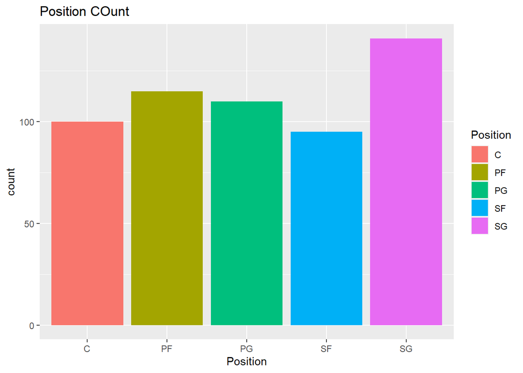

```r
ggplot(Player_Stats_Data, aes(x = Position,fill=Position)) +
  geom_bar()+ggtitle("Position COunt")
```

**Graph Analysis**:The resulting graph will show the frequency of each Position in the dataset, with each position represented by a different color bar. The height of each bar represents the count of players in that position. This graph can be used to identify the most common positions in the dataset and can be helpful in making decisions related to team composition or player recruitment

**Age Distribution**

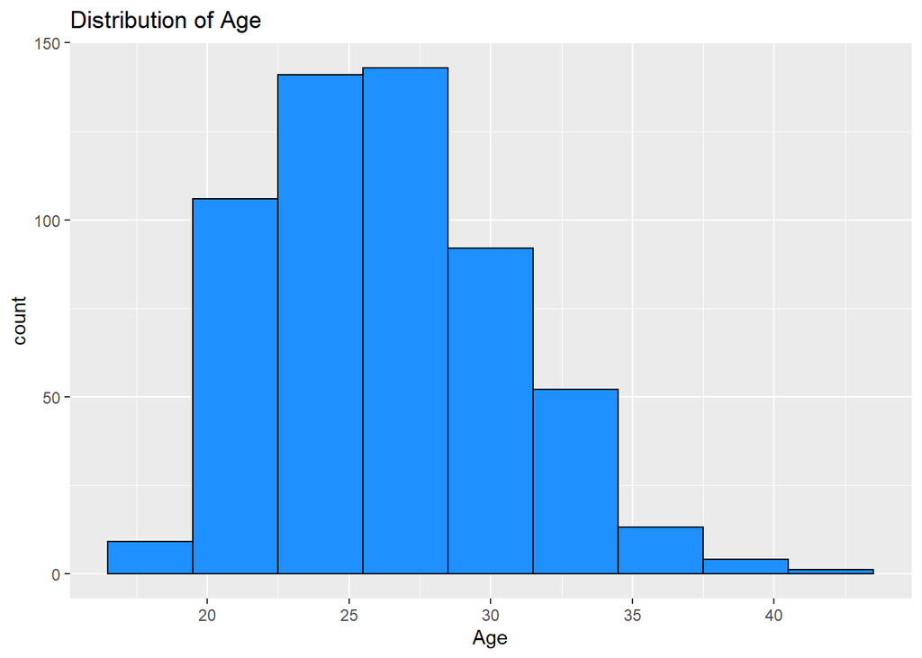

```r
ggplot(data = Player_Stats_Data) +
 geom_histogram(mapping = aes(x = Age), colour = "black", fill = "dodgerblue",binwidth = 3)+
  ggtitle("Distribution of Age")
```

Graph Analysis:The resulting graph will show the distribution of ages in the dataset, with the x-axis representing the age range and the y-axis representing the frequency of each age range. This graph can be used to identify the age distribution of players in the dataset and can be helpful in making decisions related to team composition or player recruitment

**Distrubtion Of Field_goal_percentage**

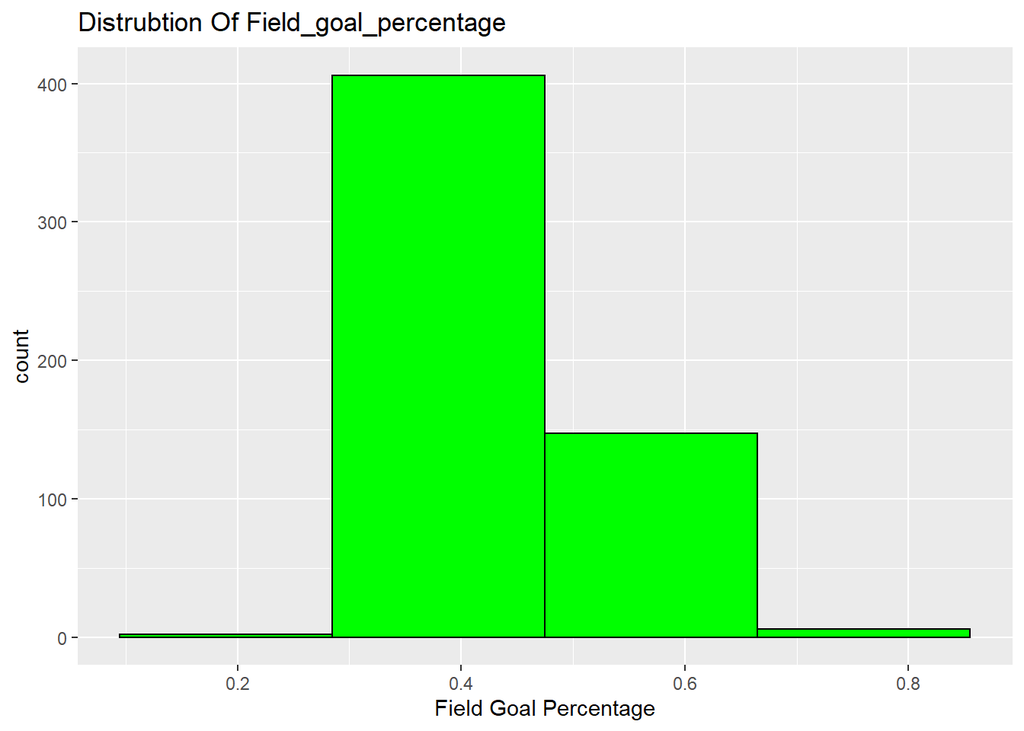

```r
ggplot(Player_Stats_Data)+geom_histogram(aes(x=Field_Goal_per),colour = "black", fill = "green",binwidth = 0.19)+
  xlab("Field Goal Percentage")+ggtitle("Distrubtion Of Field_goal_percentage")
```

Graph Analysis:This graph can be used to identify the distribution of player’s shooting ability and help in making decisions related to player selection,

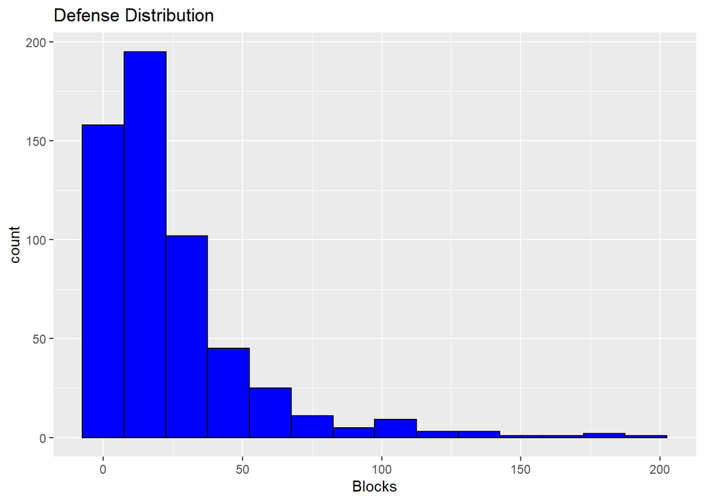

```r
ggplot(Player_Stats_Data)+geom_histogram(aes(x=Blocks),colour = "black", fill = "blue",binwidth = 15)+
  xlab("Blocks") +ggtitle("Defense Distribution")
```

Graph Analysis:This graph can be used to identify the distribution of player’s defensive ability.

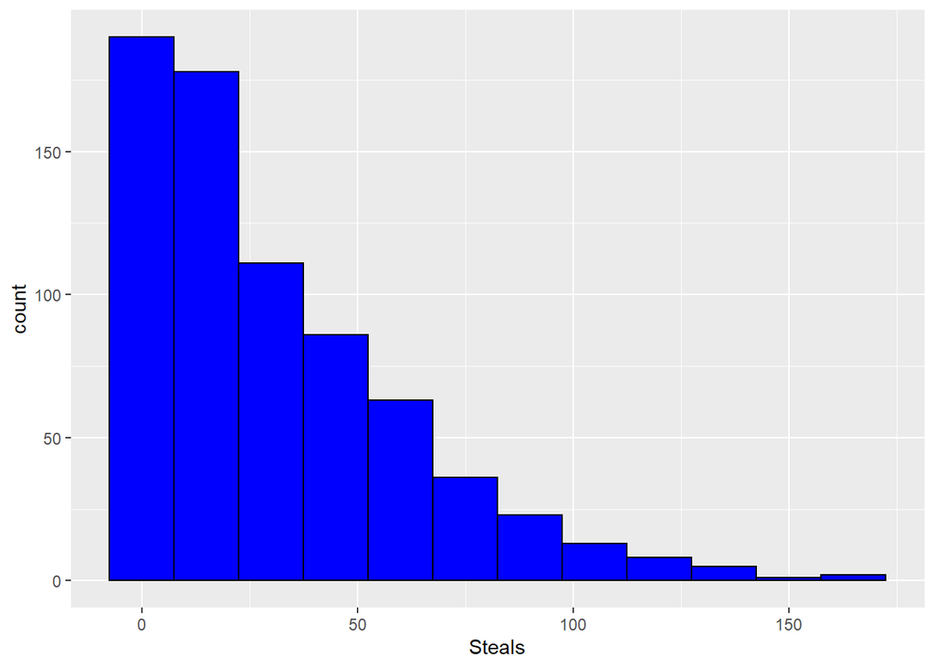

```r
ggplot(player_stats)+geom_histogram(aes(x=Steals),colour = "black", fill = "blue",binwidth = 15)+
  xlab("Steals")
```

##Distribution OF Assists.

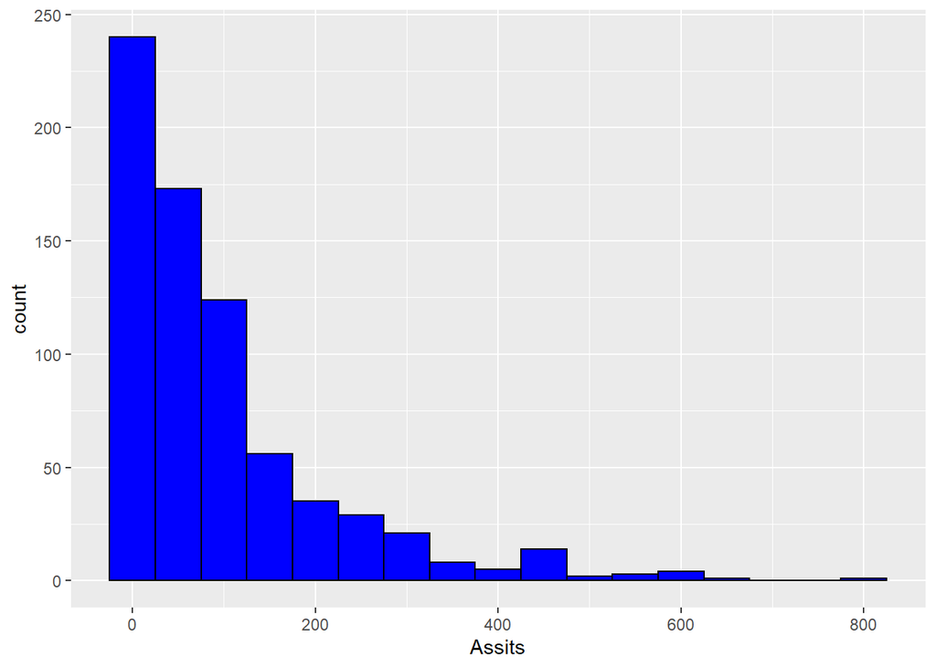

```r
ggplot(player_stats)+geom_histogram(aes(x=Assists),colour = "black", fill = "blue",binwidth = 50)+
  xlab("Assits")
```

Graph Analysis :The histogram is skewed to the right, with a long tail indicating that a few players had a high number of assists. The majority of players had fewer than 200 assists

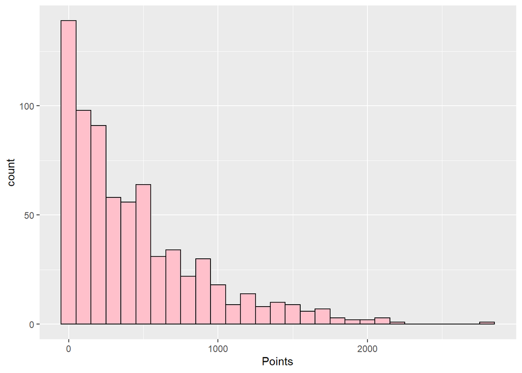

```r
ggplot(player_stats)+geom_histogram(aes(x=Points),colour = "black", fill = "pink",binwidth = 100)+
  xlab("Points")
```

Graph Analysis: The Histogram is skewed to the right , it indicates that more player lies between 0-1000 points its completely depends on th matches they played.

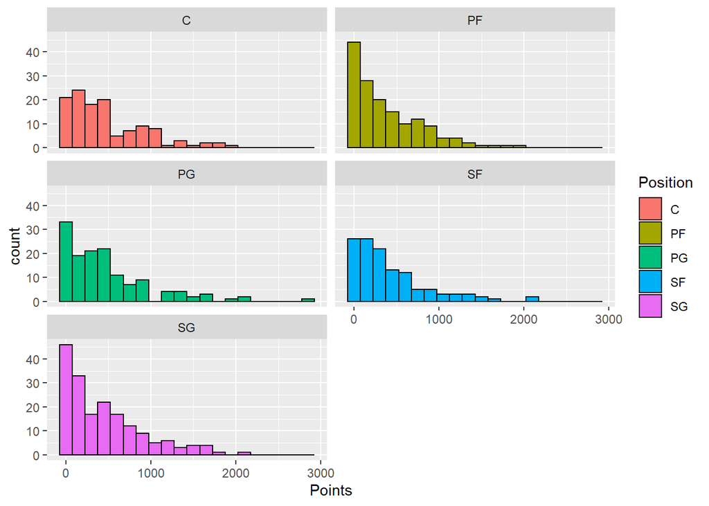

```r
ggplot(player_stats) +
 geom_histogram(aes(x = Points, fill = Position), colour = "black",binwidth = 150) +
 facet_wrap(~Position, nrow = 3) # create by Position
```

Graph Analysis: Distribution of Points Based on Position.Poisition SG has More number of Points when Compared to Other Positions.

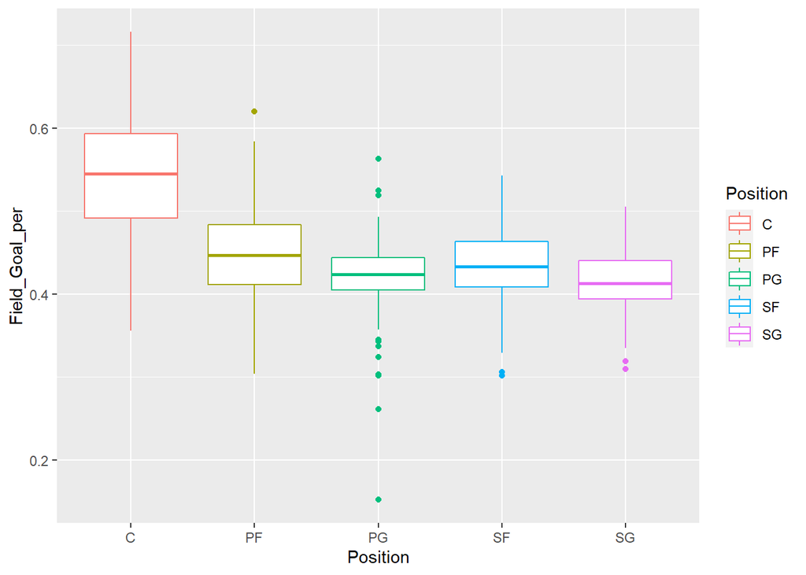

```r
ggplot(data = Player_Stats_Data) +
  geom_boxplot(mapping = aes(x =Position, y = Field_Goal_per, colour = Position))
```

**Graph Analysis**

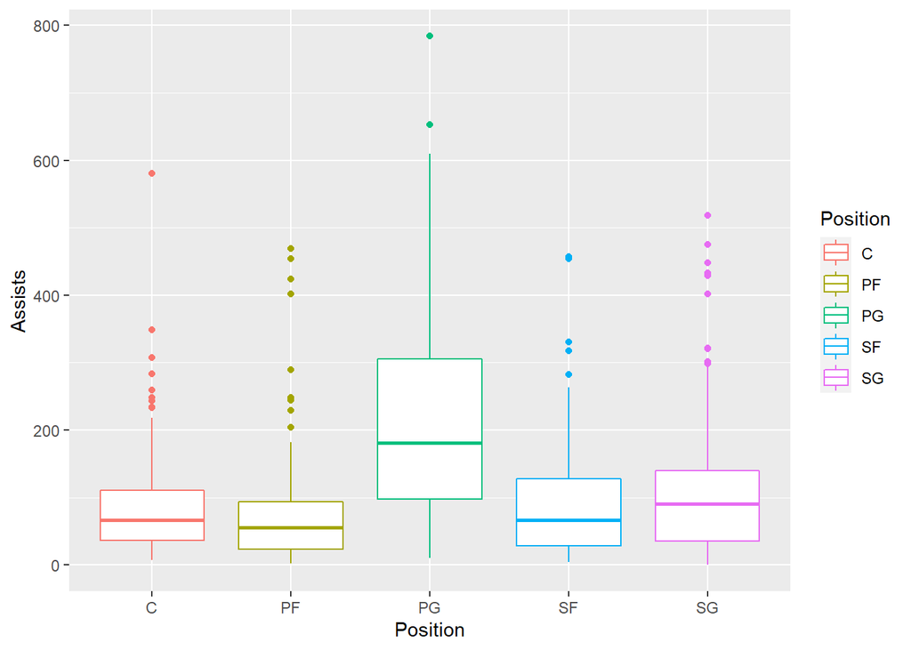

```r
 ggplot(data = Player_Stats_Data) +
  geom_boxplot(mapping = aes(x =Position, y = Assists, colour = Position))
```

**Graph Analysis** Boxplot is between count of assists based on Position. Here, Few Outliers for each Position, The reason behind is Players played Extra Game.

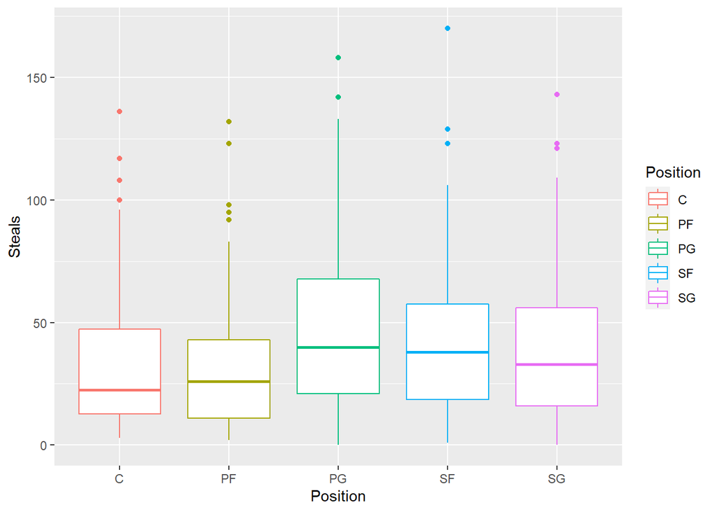

```r
ggplot(data = Player_Stats_Data) +
  geom_boxplot(mapping = aes(x =Position, y = Steals, colour = Position))
```

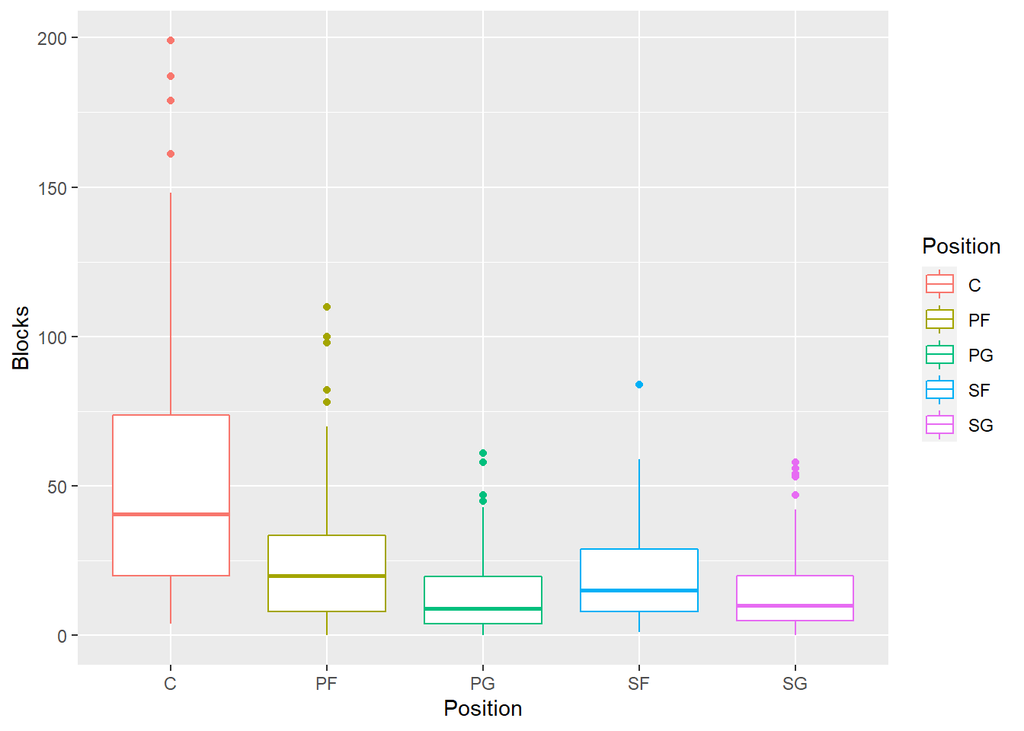

```r
ggplot(data = Player_Stats_Data) +
  geom_boxplot(mapping = aes(x =Position, y = Blocks, colour = Position))
```

# Relationship Between Variables.

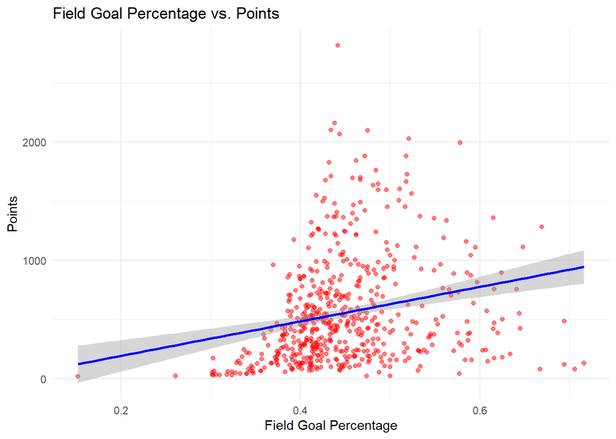

```r
ggplot(Player_Stats_Data, aes(x = Field_Goal_per, y = Points)) +
  geom_point(color = "red", alpha = 0.5) +
  geom_smooth(method = "lm", color = "blue") +
  labs(title = "Field Goal Percentage vs. Points", x = "Field Goal Percentage", y = "Points") +
  theme_minimal()
```

Understanding this relationship can be valuable for analyzing player performance or team strategies. Monitoring field goals can provide insights into offensive effectiveness, shooting accuracy, and overall scoring ability. Additionally, analyzing the relationship between field goals and points can help identify players or teams with high scoring efficiency and contribute to strategic decision-making within the game.

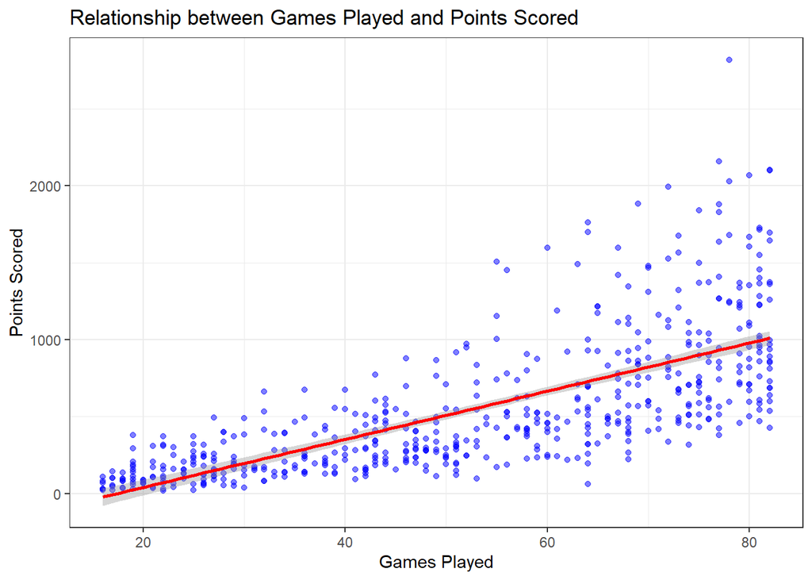

```r
ggplot(Player_Stats_Data,mapping = aes(x = Games, y = Points)) +
geom_point(alpha = 0.5, color = "blue") +
geom_smooth(method = "lm", color = "red") +
labs(title = "Relationship between Games Played and Points Scored",
x = "Games Played",
y = "Points Scored") +
theme_bw()
```

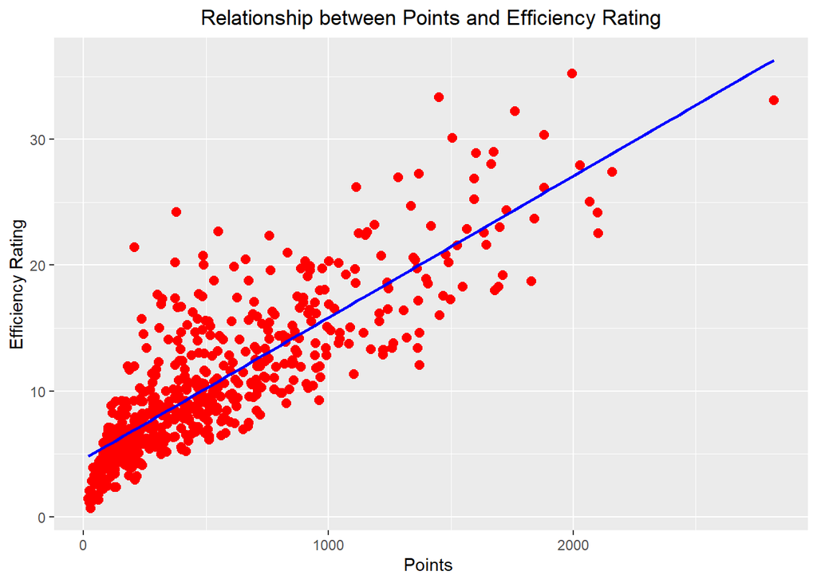

```r
ggplot(Player_Stats_Data,mapping = aes(x = Points, y = Efficiency_Per_Game)) +
 geom_point(color = "red", size = 2.5) + geom_smooth(method = "lm", color = "blue", se = FALSE) +
 xlab("Points ") + ylab("Efficiency Rating") +
 ggtitle("Relationship between Points and Efficiency Rating") +
 theme(plot.title = element_text(hjust = 0.5))
```

**Understandings** In summary, points scored by a player heavily influence their efficiency rating due to their direct contribution to offensive output and overall scoring ability. Points serve as a foundation for various statistical factors considered in efficiency rating calculations, making them a fundamental component when evaluating a player’s overall performance and efficiency on the court. There Is a Positive Correlation Between Points and Efficiency Per Game.

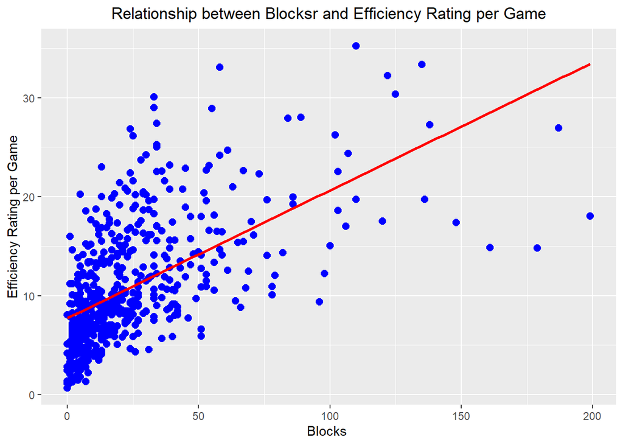

```r
ggplot(Player_Stats_Data,mapping = aes(x = Blocks, y = Efficiency_Per_Game)) +
 geom_point(color = "blue", size = 2.5) + geom_smooth(method = "lm", color = "red", se = FALSE) +
 xlab("Blocks ") + ylab("Efficiency Rating per Game") +
 ggtitle("Relationship between Blocksr and Efficiency Rating per Game") +
 theme(plot.title = element_text(hjust = 0.5))
```

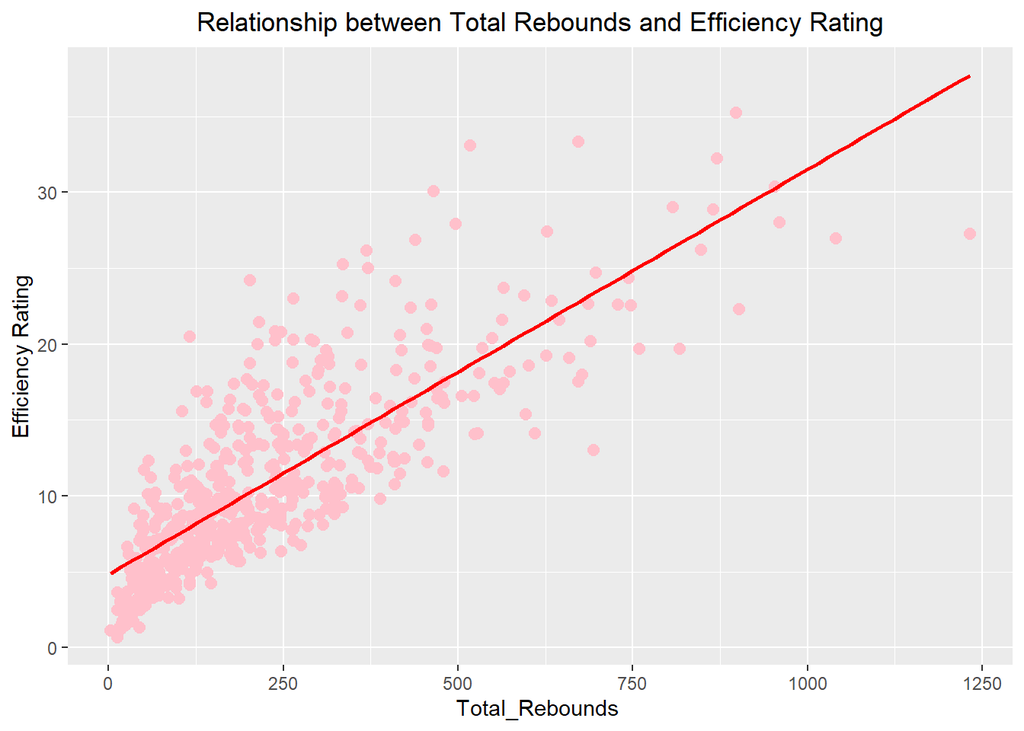

```r
ggplot(Player_Stats_Data,mapping = aes(x = Total_Rebounds, y = Efficiency_Per_Game)) +
 geom_point(color = "pink", size = 2.5) + geom_smooth(method = "lm", color = "red", se = FALSE) +
 xlab("Total_Rebounds ") + ylab("Efficiency Rating") +
 ggtitle("Relationship between Total Rebounds and Efficiency Rating") +
 theme(plot.title = element_text(hjust = 0.5))
```

**Observation**

Efficiency, Total Rebounds, points, assists, and blocks are important statistical categories in given Player data that provide insights into a player’s overall performance and contribution to the team.

**Efficiency and Rebounds**: Efficiency and rebounds can be positively related. Players who excel in rebounding tend to have more opportunities to contribute offensively and defensively, resulting in a higher overall efficiency rating. Rebounds provide additional possessions for a team, leading to increased scoring opportunities and potential assists. Additionally, strong rebounding indicates active involvement in the game, which often translates to a higher level of overall efficiency.

**Efficiency and Points**: Efficiency and points are positively correlated, as players who score more efficiently are likely to have a higher number of points. Efficient scorers capitalize on their scoring opportunities, converting a higher percentage of their field goal attempts and free throws. By making the most of their scoring chances, players can increase their overall efficiency while contributing significantly to their team’s point production.

**Efficiency and Assists**: Efficiency and assists can be positively related, as players who are efficient in their decision-making and passing are more likely to create scoring opportunities for their teammates. Effective passers with good court vision can identify open teammates, leading to high-percentage shots and assists. By making accurate and timely passes, players contribute to the overall offensive efficiency of the team, positively impacting their own efficiency rating.

**Efficiency and Blocks**: Efficiency and blocks may have a positive relationship, especially on the defensive end. Players with shot-blocking ability can alter or reject opponents’ shot attempts, providing a defensive advantage. By effectively defending the basket and deterring scoring opportunities, players can contribute to their team’s defensive efficiency. Blocked shots often lead to turnovers, transition opportunities, and disrupted offensive plays, positively impacting a player’s overall efficiency.

**Steals and Blocks** There is a positive association between Steals and blocks, indicating a correlation between the two variables. Both Steals and blocks are often related, . However, to reduce multicollinearity in the analysis, only Blocks will be considered in the model as the predictor variable. By focusing on Blocks alone, we can better isolate and analyze the specific impact of playmaking and defensive skills on the outcome of interest.

Selecting Few Variables based on above analysis.

```r
Player_performance <- Player_Stats_Data %>% select(player_name,Position,
                                                                 Games,Field_Goal_per,Three_point_per,
                                                                 Two_point_per,Effective_goal_per,
                                                                 Free_throw_per,
                                                                 Points_per_game,
                                                                 Assits_per_game,
                                                                 Steal_per_game,
                                                                 Block_per_game,
                                                                 Assists,
                                                                 Steals,
                                                                 Blocks,
                                                                 Total_Rebounds,
                                                                 Points,
                                                                 Efficiency_Per_Game)


head(Player_performance)
```

```
## # A tibble: 6 × 18
##   player…¹ Posit…² Games Field…³ Three…⁴ Two_p…⁵ Effec…⁶ Free_…⁷ Point…⁸ Assit…⁹
##   <chr>    <chr>   <dbl>   <dbl>   <dbl>   <dbl>   <dbl>   <dbl>   <dbl>   <dbl>
## 1 Giannis… PF         72   0.578   0.256   0.641   0.599   0.729    27.7    5.89
## 2 Anthony… C          56   0.517   0.331   0.547   0.54    0.794    25.9    3.89
## 3 James H… PG         78   0.442   0.368   0.528   0.541   0.879    36.1    7.51
## 4 Joel Em… C          64   0.484   0.3     0.535   0.517   0.804    27.5    3.66
## 5 Karl-An… C          77   0.518   0.4     0.562   0.572   0.836    24.4    3.36
## 6 LeBron … SF         55   0.51    0.339   0.582   0.56    0.665    27.4    8.25
## # … with 8 more variables: Steal_per_game <dbl>, Block_per_game <dbl>,
## #   Assists <dbl>, Steals <dbl>, Blocks <dbl>, Total_Rebounds <dbl>,
## #   Points <dbl>, Efficiency_Per_Game <dbl>, and abbreviated variable names
## #   ¹player_name, ²Position, ³Field_Goal_per, ⁴Three_point_per, ⁵Two_point_per,
## #   ⁶Effective_goal_per, ⁷Free_throw_per, ⁸Points_per_game, ⁹Assits_per_game
```

**Plotting Correlation Matrix Visually**

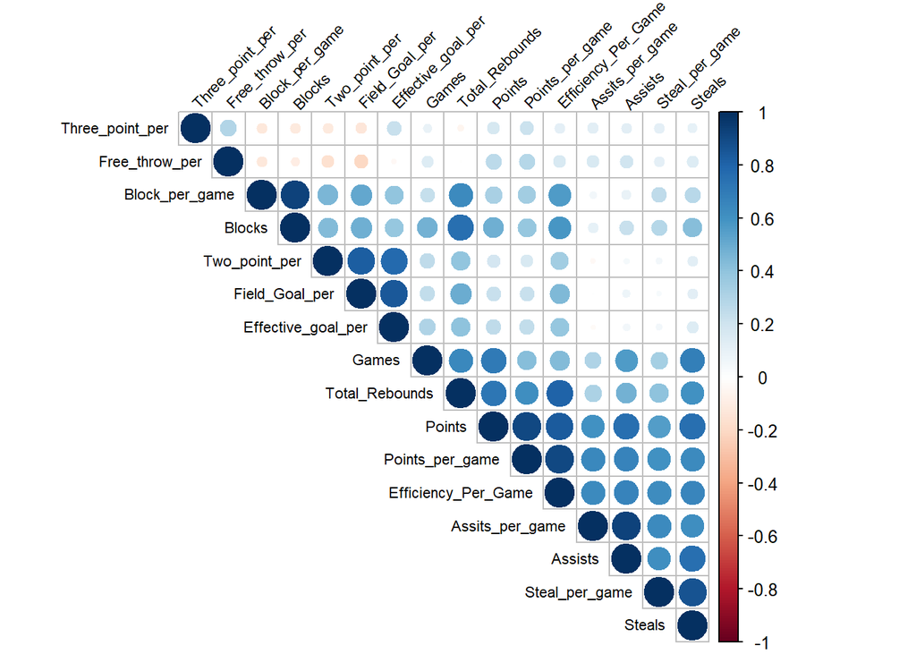

```r
corr_data <- Player_performance %>% select(!c(player_name,Position))
cor_matric <- cor(corr_data)
corrplot(cor_matric,method = "circle", type = "upper", order = "hclust",
         tl.col = "black", tl.srt = 45, tl.cex = 0.7)
```

# Player Evaluation Metrics

- To determine the best starting players, I used a combination of performance metrics .
  - 1.Total_Rebounds:): Indicates a player’s ability to secure rebounds.
  - 2.Points: A measure of a player’s scoring ability.
  - 3.Efficiency: A Mesaure of players Total Ability
  - 4.Assists : A Measure of passing Ability
  - 5.Blocks: A Measure of Players Defensive Ability

# Data Modelling

Data modeling, also known as statistical modeling or predictive modeling, involves the process of creating and analyzing mathematical models to understand and make predictions about a given dataset.

**Aim**:In order to assess player ability, we applied linear regression on metrics derived from visualization data. The goal was to predict efficiency and compare the observed and predicted values. By doing so, we aimed to demonstrate that the given variables are effective indicators of player ability.

After conducting data visualization, we identified specific metrics that appeared to be relevant in evaluating player performance. These metrics were used as independent variables in the linear regression model, while the efficiency metric served as the dependent variable.

To evaluate the model’s performance, we compared the predicted efficiency values with the observed efficiency values. If the predicted values closely aligned with the observed values, it would provide evidence that the selected variables were indeed reliable indicators of player ability.

By analyzing the results, if we find a strong correlation between the observed and predicted efficiency values, it would validate the effectiveness of the chosen variables in assessing player ability. A high degree of similarity between the observed and predicted values would support the conclusion that the identified metrics are valuable for evaluating player performance and determining their skill level.

```r
fit <- lm(data=Player_performance,Efficiency_Per_Game~Points+Total_Rebounds+Assists+Blocks)
tidy(fit,conf.int=TRUE)
```

```
## # A tibble: 5 × 7
##   term           estimate std.error statistic  p.value conf.low conf.high
##   <chr>             <dbl>     <dbl>     <dbl>    <dbl>    <dbl>     <dbl>
## 1 (Intercept)     3.58     0.198        18.1  8.49e-58  3.19      3.97
## 2 Points          0.00524  0.000519     10.1  3.60e-22  0.00423   0.00626
## 3 Total_Rebounds  0.0137   0.00126      10.9  3.89e-25  0.0112    0.0162
## 4 Assists         0.00830  0.00155       5.37 1.16e- 7  0.00526   0.0113
## 5 Blocks          0.0103   0.00675       1.53 1.27e- 1 -0.00294   0.0236
```

**The intercept (Intercept)**: The estimated intercept of the regression line is 3.577, indicating the predicted efficiency per game when all independent variables (Points, Total_Rebounds, Assists, and Blocks) are zero.

*Points*: For every unit increase in Points, the predicted efficiency per game increases by 0.0052. The coefficient is statistically significant (p < 0.001), suggesting that Points has a significant positive impact on efficiency.

*Total_Rebounds*: For every unit increase in Total_Rebounds, the predicted efficiency per game increases by 0.0137. The coefficient is statistically significant (p < 0.001), indicating that Total_Rebounds has a significant positive effect on efficiency.

*Assists*: For every unit increase in Assists, the predicted efficiency per game increases by 0.0083. The coefficient is statistically significant (p < 0.001), indicating that Assists have a significant positive influence on efficiency.

*Blocks*: The coefficient for Blocks is 0.0103, but it is not statistically significant (p = 0.127). This suggests that Blocks may not have a significant impact on efficiency, given the data available.

```r
summary(fit)
```

```
##
## Call:
## lm(formula = Efficiency_Per_Game ~ Points + Total_Rebounds +
##     Assists + Blocks, data = Player_performance)
##
## Residuals:
##     Min      1Q  Median      3Q     Max
## -4.9035 -1.9299 -0.6901  0.9657 15.2156
##
## Coefficients:
##                 Estimate Std. Error t value Pr(>|t|)
## (Intercept)    3.5771954  0.1978890  18.077  < 2e-16 ***
## Points         0.0052441  0.0005187  10.110  < 2e-16 ***
## Total_Rebounds 0.0136956  0.0012585  10.882  < 2e-16 ***
## Assists        0.0082974  0.0015454   5.369 1.16e-07 ***
## Blocks         0.0103291  0.0067534   1.529    0.127
## ---
## Signif. codes:  0 '***' 0.001 '**' 0.01 '*' 0.05 '.' 0.1 ' ' 1
##
## Residual standard error: 2.812 on 556 degrees of freedom
## Multiple R-squared:  0.7914, Adjusted R-squared:  0.7899
## F-statistic: 527.4 on 4 and 556 DF,  p-value: < 2.2e-16
```

**Why Given Model is Good**

*Residual Standard Error (RSE)*: The RSE is a measure of the average deviation of the observed values from the predicted values. In this model, the RSE is 2.812, indicating that, on average, the predicted efficiency per game deviates from the observed values by approximately 2.812 units.

*Multiple R-squared*: The multiple R-squared value measures the proportion of the variance in the dependent variable (Efficiency_Per_Game) that can be explained by the independent variables (Points, Total_Rebounds, Assists, Blocks). In this model, the multiple R-squared is 0.7914, which means that approximately 79.14% of the variability in the efficiency per game can be explained by the independent variables.

*F-statistic and p-value*: The F-statistic tests the overall significance of the linear regression model. In this case, the F-statistic is 527.4 with 4 and 556 degrees of freedom. The associated p-value is extremely small (p < 2.2e-16), indicating strong evidence to reject the null hypothesis that all the regression coefficients are zero. This suggests that the model, as a whole, is statistically significant in explaining the variability in the dependent variable.

Taken together, the model exhibits a reasonably good fit to the data, as indicated by a relatively high multiple R-squared value and a low p-value for the overall model.

```r
Player_performance$predicted <- predict(fit)
Player_performance$predicted <- round(Player_performance$predicted,2)
Player_performance <- Player_performance %>% arrange(desc(Player_performance$Efficiency_Per_Game))
head(Player_performance)
```

```
## # A tibble: 6 × 19
##   player…¹ Posit…² Games Field…³ Three…⁴ Two_p…⁵ Effec…⁶ Free_…⁷ Point…⁸ Assit…⁹
##   <chr>    <chr>   <dbl>   <dbl>   <dbl>   <dbl>   <dbl>   <dbl>   <dbl>   <dbl>
## 1 Giannis… PF         72   0.578   0.256   0.641   0.599   0.729    27.7    5.89
## 2 Anthony… C          56   0.517   0.331   0.547   0.54    0.794    25.9    3.89
## 3 James H… PG         78   0.442   0.368   0.528   0.541   0.879    36.1    7.51
## 4 Joel Em… C          64   0.484   0.3     0.535   0.517   0.804    27.5    3.66
## 5 Karl-An… C          77   0.518   0.4     0.562   0.572   0.836    24.4    3.36
## 6 LeBron … SF         55   0.51    0.339   0.582   0.56    0.665    27.4    8.25
## # … with 9 more variables: Steal_per_game <dbl>, Block_per_game <dbl>,
## #   Assists <dbl>, Steals <dbl>, Blocks <dbl>, Total_Rebounds <dbl>,
## #   Points <dbl>, Efficiency_Per_Game <dbl>, predicted <dbl>, and abbreviated
## #   variable names ¹player_name, ²Position, ³Field_Goal_per, ⁴Three_point_per,
## #   ⁵Two_point_per, ⁶Effective_goal_per, ⁷Free_throw_per, ⁸Points_per_game,
## #   ⁹Assits_per_game
```

**Plot Between Observed and Predicted**

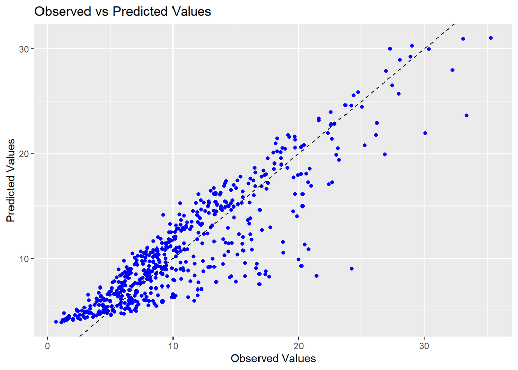

```r
ggplot(Player_performance, aes(x = Efficiency_Per_Game, y = predicted)) +
  geom_point(color="blue") +
  geom_abline(intercept = 0, slope = 1, linetype = "dashed") +
  xlab("Observed Values") +
  ylab("Predicted Values") +
  ggtitle("Observed vs Predicted Values")
```

Observations: This will create a scatter plot with the observed values on the x-axis and the predicted values on the y-axis. The dashed line represents a 45-degree line, which indicates perfect prediction..

```r
player_stats_salary <- merge(Player_performance,salary,by="player_name")
player_stats_salary <- player_stats_salary %>% arrange(desc(player_stats_salary$Efficiency_Per_Game))

player_stats_salary <- player_stats_salary %>% mutate(Total_rebound_per_game=Total_Rebounds/Games)
head(player_stats_salary)
```

```
##             player_name Position Games Field_Goal_per Three_point_per
## 1 Giannis Antetokounmpo       PF    72          0.578           0.256
## 2         Anthony Davis        C    56          0.517           0.331
## 3          James Harden       PG    78          0.442           0.368
## 4           Joel Embiid        C    64          0.484           0.300
## 5    Karl-Anthony Towns        C    77          0.518           0.400
## 6          LeBron James       SF    55          0.510           0.339
##   Two_point_per Effective_goal_per Free_throw_per Points_per_game
## 1         0.641              0.599          0.729           27.69
## 2         0.547              0.540          0.794           25.93
## 3         0.528              0.541          0.879           36.13
## 4         0.535              0.517          0.804           27.52
## 5         0.562              0.572          0.836           24.42
## 6         0.582              0.560          0.665           27.36
##   Assits_per_game Steal_per_game Block_per_game Assists Steals Blocks
```

[output cut: 20 more lines]

```r
Selected_data <- player_stats_salary %>% select(player_name,player_id,Position,
                                                Three_point_per,Two_point_per,
                                                Effective_goal_per,
                                                Points_per_game,
                                                Assits_per_game,
                                                Total_rebound_per_game,
                                                Efficiency_Per_Game,
                                                salary)


Selected_data <- Selected_data %>% mutate(Salary_in_millions=round(salary/1000000,2))
head(Selected_data)
```

```
##             player_name player_id Position Three_point_per Two_point_per
## 1 Giannis Antetokounmpo        20       PF           0.256         0.641
## 2         Anthony Davis       135        C           0.331         0.547
## 3          James Harden       224       PG           0.368         0.528
## 4           Joel Embiid       166        C           0.300         0.535
## 5    Karl-Anthony Towns       522        C           0.400         0.562
## 6          LeBron James       278       SF           0.339         0.582
##   Effective_goal_per Points_per_game Assits_per_game Total_rebound_per_game
## 1              0.599           27.69            5.89              12.472222
## 2              0.540           25.93            3.89              12.000000
## 3              0.541           36.13            7.51               6.641026
## 4              0.517           27.52            3.66              13.609375
## 5              0.572           24.42            3.36              12.389610
## 6              0.560           27.36            8.25               8.454545
##   Efficiency_Per_Game   salary Salary_in_millions
## 1            35.25000 24157304              24.16
## 2            33.35714 25434263              25.43
## 3            33.08974 30570000              30.57
## 4            32.21875 25467250              25.47
## 5            30.36364  7839435               7.84
## 6            30.09091 35654150              35.65
```

```r
Total_Budget <- 118
max_budget <- 0.70*118
```

**Findings and Recommendations**

```r
head(Selected_data %>% filter(Salary_in_millions<max_budget ) %>% arrange(desc(Efficiency_Per_Game)),30)
```

```
##              player_name player_id Position Three_point_per Two_point_per
## 1  Giannis Antetokounmpo        20       PF           0.256         0.641
## 2          Anthony Davis       135        C           0.331         0.547
## 3           James Harden       224       PG           0.368         0.528
## 4            Joel Embiid       166        C           0.300         0.535
## 5     Karl-Anthony Towns       522        C           0.400         0.562
## 6           LeBron James       278       SF           0.339         0.582
## 7      Russell Westbrook       548       PG           0.290         0.481
## 8           Nikola Jokic       291        C           0.307         0.569
## 9         Nikola Vucevic       535        C           0.364         0.549
## 10          Kevin Durant       160       SF           0.353         0.587
## 11           Paul George       197       SF           0.386         0.484
## 12        Andre Drummond       157        C           0.132         0.548
## 13           Rudy Gobert       203        C           0.335         0.669
## 14         Kawhi Leonard       324       SF           0.371         0.542
```

[output cut: 78 more lines]

```r
Desired_df <- Selected_data %>% select(player_name,
                                       Position,
                                       Efficiency_Per_Game,
                                       Salary_in_millions)
head(Desired_df,30)
```

```
##              player_name Position Efficiency_Per_Game Salary_in_millions
## 1  Giannis Antetokounmpo       PF            35.25000              24.16
## 2          Anthony Davis        C            33.35714              25.43
## 3           James Harden       PG            33.08974              30.57
## 4            Joel Embiid        C            32.21875              25.47
## 5     Karl-Anthony Towns        C            30.36364               7.84
## 6           LeBron James       SF            30.09091              35.65
## 7      Russell Westbrook       PG            29.01370              35.66
## 8           Nikola Jokic        C            28.88750              25.47
## 9         Nikola Vucevic        C            28.02500              12.75
## 10          Kevin Durant       SF            27.92308              30.00
## 11           Paul George       SF            27.40260              30.56
## 12        Andre Drummond        C            27.25316              25.43
## 13           Rudy Gobert        C            26.95062              23.49
## 14         Kawhi Leonard       SF            26.86667              23.11
```

[output cut: 16 more lines]

```r
unique(Desired_df$Position)
```

```
## [1] "PF" "C"  "PG" "SF" "SG"
```

**Player Pick For Position (PF)**

```r
head(Desired_df %>% filter(Position=="PF"),10)
```

```
##              player_name Position Efficiency_Per_Game Salary_in_millions
## 1  Giannis Antetokounmpo       PF            35.25000              24.16
## 2          Blake Griffin       PF            23.69333              31.87
## 3           John Collins       PF            23.21311               2.30
## 4          Julius Randle       PF            22.84932               8.64
## 5          Tobias Harris       PF            22.38182              14.80
## 6          Tobias Harris       PF            21.59756              14.80
## 7          Pascal Siakam       PF            20.38750               1.54
## 8             Kevin Love       PF            20.22727              24.12
## 9          Tobias Harris       PF            20.00000              14.80
## 10       Lauri Markkanen       PF            19.73077               4.54
```

Pick for PF * Position : PF * Player Name: Giannis Antetokounmpo  
* Points_per_Game:27.69 * Assists_per_Game:5.89  
* Rebound_Per_Game:12.47 * Efficiency:35.25000 * Salary_in_milions:24.16

**Justification** Giannis Antetokounmpo (PF): Giannis Antetokounmpo is recommended as the Point Forward for the Chicago Bulls due to his strong performance in the 2018-19 season. He averaged 27.69 points, 12.4 rebounds, and 5.89 assists per game while having a salary of $24.16. With a Efficiency of 35.25 Which Highest among all player, Giannis provides a solid contribution to the team at a relatively Perfect salary with his shooting ability.

**Player Pick For Position (sG)**

```r
head(Desired_df %>% filter(Position=="SG"),10)
```

```
##         player_name Position Efficiency_Per_Game Salary_in_millions
## 1      Bradley Beal       SG            24.17073              25.43
## 2      Jrue Holiday       SG            23.13433              26.64
## 3      Devin Booker       SG            23.01562               3.31
## 4     DeMar DeRozan       SG            22.57143              27.74
## 5       Luka Doncic       SG            21.58333               6.57
## 6      Jimmy Butler       SG            20.73846              19.84
## 7       Zach LaVine       SG            20.19048              19.50
## 8    Victor Oladipo       SG            18.75000              21.00
## 9  Donovan Mitchell       SG            18.70130               3.11
## 10      Buddy Hield       SG            18.26829               3.83
```

- Position :SG
- Devin Booker:Shooting Guard
- Points_per_Game:26.56
- Assists_per_Game:6.77
- Rebound_Per_Game:4.140625
- Efficiency:23.01562
- Salary_in_millions:3.31

Total Budget we used till now is 27.47

**Justification** Devin Booker:Devin Booker is suggested as the starting shooting guard for his impressive scoring ability. He averaged 26.56 points per game, along with 4.14 rebounds and 6.7 assists.His Salary is very low with outstanding efficiency per game. My pick for Shooting Guard is Devin Booker.

```r
head(Desired_df %>% filter(Position=="C"),10)
```

```
##           player_name Position Efficiency_Per_Game Salary_in_millions
## 1       Anthony Davis        C            33.35714              25.43
## 2         Joel Embiid        C            32.21875              25.47
## 3  Karl-Anthony Towns        C            30.36364               7.84
## 4        Nikola Jokic        C            28.88750              25.47
## 5      Nikola Vucevic        C            28.02500              12.75
## 6      Andre Drummond        C            27.25316              25.43
## 7         Rudy Gobert        C            26.95062              23.49
## 8        Clint Capela        C            26.22388              15.79
## 9   LaMarcus Aldridge        C            24.35802              22.35
## 10  Jonas Valanciunas        C            24.21053              16.54
```

- Position :C
- Player_name:Karl-Anthony Towns
- Points_per_Game:24.42
- Assists_per_Game:3.36
- Rebound_Per_Game:12.38
- Efficiency:30.3
- Salary_in_millions:7.84

**Justification**

Karl-Anthony Towns, a Center (C), is a highly recommended player due to his exceptional performance in various statistical categories. With an impressive average of 24.42 Points per Game, he consistently provides a significant scoring contribution for his team. Towns’ scoring ability is complemented by his average of 3.36 Assists per Game.

In terms of salary, Towns’ earnings of 7.84 million dollars reflect his value as a highly skilled and impactful player. Despite his significant contributions on the court, his salary remains relatively reasonable.

In conclusion, Karl-Anthony Towns’ remarkable scoring ability, playmaking skills, dominant rebounding, high efficiency, and reasonable salary make him a highly recommended player in the Center position.

Total Budget we used till now is 35.31

```r
head(Desired_df %>% filter(Position=="SF"),10)
```

```
##         player_name Position Efficiency_Per_Game Salary_in_millions
## 1      LeBron James       SF            30.09091              35.65
## 2      Kevin Durant       SF            27.92308              30.00
## 3       Paul George       SF            27.40260              30.56
## 4     Kawhi Leonard       SF            26.86667              23.11
## 5      Jimmy Butler       SF            20.73846              19.84
## 6  Danilo Gallinari       SF            20.58824              21.59
## 7      Jimmy Butler       SF            20.29091              19.84
## 8   Khris Middleton       SF            18.54545              13.00
## 9  Robert Covington       SF            16.86364              10.46
## 10     Jayson Tatum       SF            16.50633               6.70
```

```r
head(Desired_df %>% filter(Position=="PG"),10)
```

```
##          player_name Position Efficiency_Per_Game Salary_in_millions
## 1       James Harden       PG            33.08974              30.57
## 2  Russell Westbrook       PG            29.01370              35.66
## 3      Stephen Curry       PG            26.14493              37.46
## 4       Kyrie Irving       PG            25.25373              20.10
## 5     Damian Lillard       PG            25.02500              27.98
## 6        Ben Simmons       PG            24.70886               6.43
## 7       Kemba Walker       PG            22.54878              12.00
## 8        Mike Conley       PG            20.84286              30.52
## 9          John Wall       PG            20.46875              19.17
## 10        Chris Paul       PG            20.31034              35.65
```

**Summary:**

- As a data analyst for the Chicago Bulls, my task was to identify the best five starting players for the team within a budget of $118 million for the upcoming 2019-20 NBA season. The team’s performance in the previous season was ranked 27th out of 30 based on win-loss record, and the budget allocated for player contracts ranked 26th out of 30.
- To address this task, I conducted a thorough analysis of player performance, taking into consideration their position, statistical performance, and cost-effectiveness. I aimed to find a balance between player skills, team needs, and financial constraints.
- Using available data, I analyzed various factors such as points per game, assists per game, rebounds per game, efficiency ratings, and salaries of players from the previous season.
- By applying rigorous analysis and considering the specific requirements of each position, I identified the best players for the Chicago Bulls. The selection criteria included their performance, potential for improvement, and financial feasibility.
- The knitr report generated through R Markdown presents a comprehensive overview of the analysis, highlighting the strengths, contributions, and potential value of the selected players. It also provides insights into how the chosen players align with the team’s objectives and how their skills can positively impact the team’s performance in the upcoming season.
- The analysis aims to assist the general manager in making informed decisions regarding player selection and team budget allocation. By strategically choosing the best starting players within the given budget, the Chicago Bulls can enhance their chances of improving their ranking and achieving better performance in the upcoming NBA season.

**References and Links**

1.[Click here to view the More Detail About Efficiency](https://en.wikipedia.org/wiki/Efficiency_(basketball) 2.[Nba Stats](https://www.nba.com/stats/players/shooting-efficiency) -: David Card,May 2011. An Analysis of On-Court Performance and Its Effects on Revenues,[https://www.econ.berkeley.edu/sites/default/files/li_harrison.pdf]

-: Richard A Hofler a, James E Payne ,Measuring efficiency in the National Basketball Association,[https://www.sciencedirect.com/science/article/abs/pii/S0165176597000839]